# Fortress runs data analysis v1

### Deprecated

Please see newer version v2.

### Goal

The goal of this analysis is to provide basis for a function to generate a realistic fortress room and enemies given the following parameters:

- Room level
- Player count
- Runestone levels

### Data load and preparation

```
[1] \Loaded 101 overall unique runs\
[1] \Loaded 92 unique runs with 1 player\
```

### Dataset size:

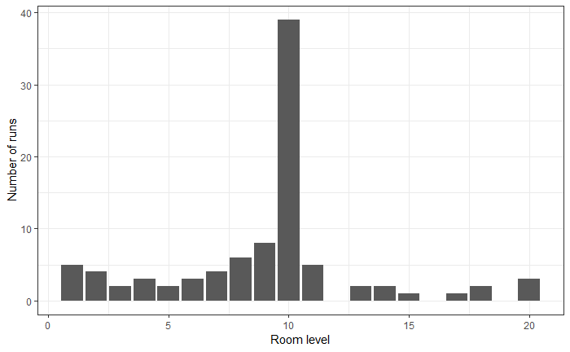

### Difficulty

When removing the player count multiplier (see [link](https://docs.google.com/spreadsheets/d/1jtBjdncxspRt51K048islZdEPTZ06yBKuZX7_MBzprI/edit#gid=0)), difficulty clearly scales quadratically with room number (for a single player):

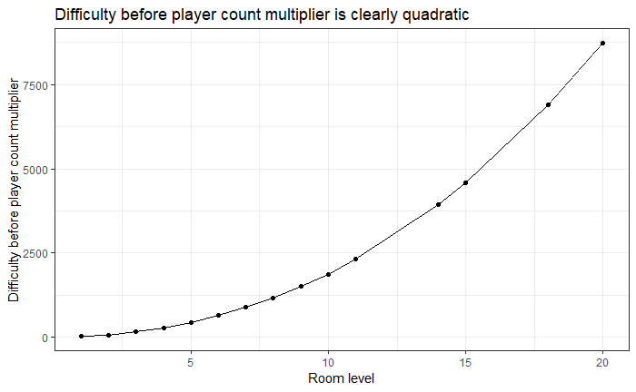

### Number of enemies (in relation to difficulty)

The following charts all use difficulty for the X axis. Hopefully this number alone can be used to describe the following characteristic of a fortress room:

- Average number of enemies (elites count as 2)
- Average enemy level
- Average enemy difficulty (stars)
- Average proficiency

I explicitly use difficulty instead of a combination of runestone levels, player count and room level.

For this graph, I count the number of elites as 2 enemies.

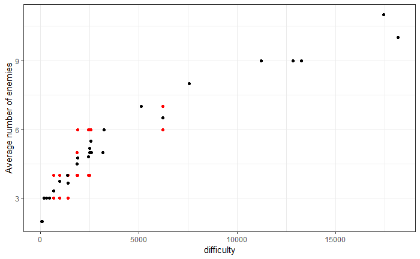

### Average enemy level (in relation to difficulty)

Here, the picture is clearer. The average enemy level seems to be a root function in relation to difficulty (which would make it linear in relation to room level). The following graph also contains min and max values for each difficulty. For example, a difficulty of 39 (Ruins I, runestone level 1, 1 player) can apparently have an average enemy level anywhere between 2 and 5.

[figure not shown]

# Average enemy difficulty (stars)

More data is needed here. Perhaps this too is a root function.

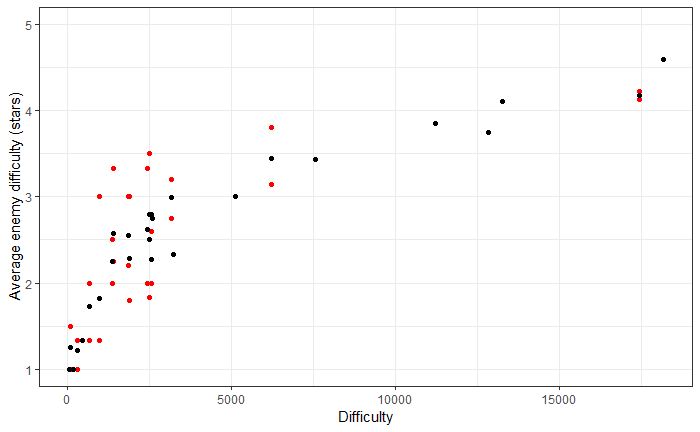

# Average proficiency

The current theory is that when doing a solo fortress run you will be proficient against a certain percentage of enemies. I have seen values between 50% and 60%.

This graph disputes that theory and shows that this percentage may depend on difficulty/room level and is not in fact constant. However, more data is needed to model this relation.

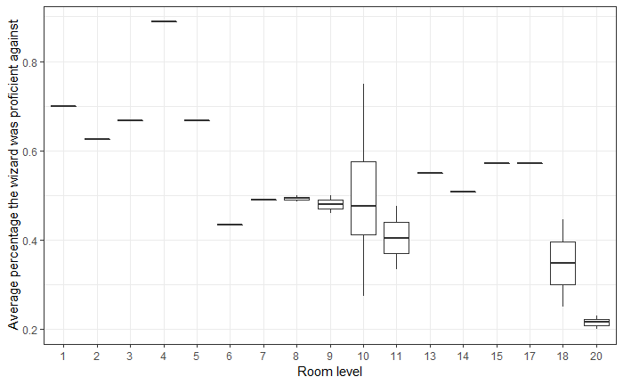

### Computing a difficulty “budget” per enemy

When generating a room one approach could be to compute a difficulty “budget” per enemy, which would translate to enemy difficulty and enemy level.

This [post](https://www.reddit.com/r/harrypotterwu/comments/csgsdd/all_about_combat_damage_what_i_know_or_i_think_i/?st=k0gijz3i&sh=acd204fd) suggests the following might hold:

$difficulty \approx 2 * \sum enemyDifficulty * enemyLevel (1+isElite)$

This relation seems to be a good approach for room levels > 7 but inaccurate for easier rooms.

The following chart shows how the factor 2 may be computed:

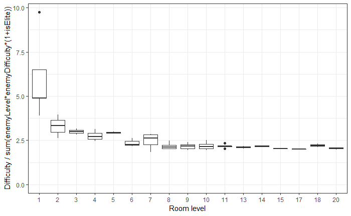